# Analysis of Covid-19 tests statistics

## Importing libraries and setting-up notebook

```python
import pandas as pd
import os
from matplotlib import pyplot as plt
import plotly.express as px
import plotly.io as pio
import plotly.graph_objects as go
import plotly.offline as py
import warnings
warnings.simplefilter('ignore')
```

```python
pio.renderers.default = 'notebook'
```

```python
import numpy as np
```

```python
import re
```

```python
pd.set_option("display.min_rows", 100)
```

```python
pd.set_option("display.max_rows", 400)
```

```python
pd.set_option("display.max_columns", 100)
```

```python
pd.set_option('display.max_colwidth', None)
```

```python
filepath = "C:\\Users\\edidd\\Documents\\Ubiqum\\Data Analytics Course\\covid19\\resources\\COVID-19 Science Report Diagnostics V14.pdf"
```

## Reading PDF into df with camelot

Statistics of many different, globally available, Covid-19 tests procedures has been gathered in the "COVID-19 Science Report: Diagnostics" of the Saw Swee Hock School of Public Health of the National University of Singapore. The report is available in PDF format. So, the first step is to convert the tabular data from the PDF into a pandas dataframe. Different open source tools have been tested (tabula, pdfplumber and camelot) being camelot the one producing the best results. Camelot's flexibility allows, by tweaking the parameters, to get a perfect extraction of the tabular data in the pdf.

```python
import camelot
```

```python
tables_camelot = camelot.read_pdf(
    filepath,
    pages= "all",
    strip_text='\n',
    layout_kwargs={'detect_vertical': False},
    flag_size=True,
    line_scale=60
)
```

```python
tables1 = camelot.read_pdf(
    filepath,
    pages= "33",
    strip_text='\n',
    layout_kwargs={'detect_vertical': False},
    flag_size=True,
    line_scale=60
)
```

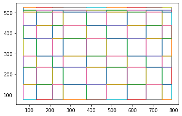

```python
camelot.plot(tables1[0], kind='grid')
plt.show()
```

```python
len(tables_camelot)
```

```
57
```

```python
tables_camelot[0].df.shape[1]
```

```
1
```

```python
tables_camelot[3].parsing_report
```

```
{'accuracy': 99.79, 'whitespace': 20.63, 'order': 1, 'page': 14}
```

```python
# tests_df = pd.DataFrame()
# for i in range(0, 43):
#     tests_df = pd.concat([tests_df, tables_camelot[i].df])
```

```python
tests_df = pd.DataFrame()
for i in tables_camelot:
    if i.df.shape[1] == 9:
        tests_df = pd.concat([tests_df, i.df])
```

```python
tests_df.head(3)
```

|  | 0 | 1 | 2 | 3 | 4 | 5 | 6 | 7 | 8 |
| --- | --- | --- | --- | --- | --- | --- | --- | --- | --- |
| 0 | Molecular tests (rRT-PCR) |  |  |  |  |  |  |  |  |
| 1 | Type | Organisation | Date | Test | Sensitivity | Specificity | Availability | Turnaround | Costs |
| 2 | rRT-PCR | Charité Institute of Virology, Berlin, Germany <s>1,99</s> | 13 Jan 2020 | Primer and Probe First line screening assay: E gene assay Confirmatory assay: RdRp gene assay Additional confirmatory assay: N gene assay | First line screening assay Technical LOD: 5.2 RNA copies/reaction, at 95% hit rate 95% CI: 3.7-9.6 RNA copies/reaction. Confirmatory assay Technical LOD: 3.8 RNA copies/reaction, at 95% hit rate 95% C… | Chemical stability No positive signal detected for non-specific reactivity of oligonucleotides. Cross-reactivity with other coronaviruses No reactivity with any of three assays for five coronaviruses:… | Available • SARS-CoV genomic RNA as positive control. | 47 min 15 sec of cycle time (plus probe) for each assay | (no info) |

Set columns names the same as 2nd row

```python
tests_df.columns = tests_df.iloc[1]
```

Drop first two rows, which have titles and column names, repectively

```python
tests_df.drop([0,1], inplace = True)
```

Reset index, in order to have a continuous index starting with 0

```python
tests_df.reset_index(inplace = True, drop = True)
```

Dropping rows containing sub-titles and rows with only white spaces

```python
tests_df.columns
```

```
Index(['Type', 'Organisation', 'Date', 'Test', 'Sensitivity', 'Specificity',
       'Availability', 'Turnaround', 'Costs'],
      dtype='object', name=1)
```

```python
tests_df = tests_df.loc[~((tests_df.Organisation == "") &
                          (tests_df.Date == "") &
                          (tests_df.Test == "") &
                          (tests_df.Sensitivity == "") &
                          (tests_df.Specificity == "") &
                          (tests_df.Availability == "") &
                          (tests_df.Turnaround == "") &
                          (tests_df.Costs == "")
                         ) ,:]
```

Reseting index

```python
tests_df.reset_index(inplace = True, drop = True)
```

Concatenating rows previously splitted on the original PDF due to page break

Index of broken rows

```python
index_merge = tests_df.loc[(tests_df.Type.shift(-1) == ""), :].index
```

Dataframe containing only splitted rows

```python
to_merge = tests_df.loc[(tests_df.Type.shift(-1) == "") | (tests_df.Type == ""), :]
```

Dataframe containing merged rows

```python
merged = to_merge.apply(lambda x: x.str.cat(x.shift(-1), sep = " "), axis = 0).loc[index_merge]
```

Replacing splitted rows with merged ones

```python
tests_df.loc[(tests_df.Type.shift(-1) == ""), :] = merged
```

```python
tests_df = tests_df.loc[tests_df.Type != "", :]
```

```python
tests_df.reset_index(inplace = True, drop = True)
```

```python
tests_df = tests_df.replace("", np.nan)
```

```python
tests_df.isnull().any()
```

```
1
Type            False
Organisation    False
Date             True
Test            False
Sensitivity      True
Specificity      True
Availability    False
Turnaround       True
Costs            True
dtype: bool
```

```python
tests_df.head(3)
```

| 1 | Type | Organisation | Date | Test | Sensitivity | Specificity | Availability | Turnaround | Costs |
| --- | --- | --- | --- | --- | --- | --- | --- | --- | --- |
| 0 | rRT-PCR | Charité Institute of Virology, Berlin, Germany <s>1,99</s> | 13 Jan 2020 | Primer and Probe First line screening assay: E gene assay Confirmatory assay: RdRp gene assay Additional confirmatory assay: N gene assay | First line screening assay Technical LOD: 5.2 RNA copies/reaction, at 95% hit rate 95% CI: 3.7-9.6 RNA copies/reaction. Confirmatory assay Technical LOD: 3.8 RNA copies/reaction, at 95% hit rate 95% C… | Chemical stability No positive signal detected for non-specific reactivity of oligonucleotides. Cross-reactivity with other coronaviruses No reactivity with any of three assays for five coronaviruses:… | Available • SARS-CoV genomic RNA as positive control. | 47 min 15 sec of cycle time (plus probe) for each assay | (no info) |
| 1 | rRT-PCR | Charité Institute of Virology, Berlin, Germany <s>1,12</s> | 17 Jan 2020 | Primer and Probe First line screening assay: E gene assay Confirmatory assay: RdRp gene assay | First line screening assay Technical LOD: 5.2 RNA copies/reaction, at 95% hit rate 95% CI: 3.7-9.6 RNA copies/reaction. Confirmatory assay Technical LOD: 3.8 RNA copies/reaction, at 95% hit rate 95% C… | Chemical stability No positive signal detected for non-specific reactivity of oligonucleotides. Cross-reactivity with other coronaviruses No reactivity with any of three assays for five coronaviruses:… | Available • SARS-CoV genomic RNA as positive control. • Synthetic control RNA for SARS-CoV-2 E gene assay is available via EVAg. • Synthetic control for SARS-CoV-2 RdRp is expected to be available via… | 47 min 15 sec of cycle time (plus probe) for each assay | (no info) |
| 2 | rRT-PCR | School of Public Health, The University of Hong Kong (HKU)<s>13,14</s> | 16 Jan 2020 | Primer and Probe Assay 1 (Target: ORF1b-nsp14 gene) Assay 2 (Target: N gene) | Positive control using SARS-CoV RNA Wide dynamic range of 2<s>-4</s> to 2000 TCID<s>50</s>/reaction. | Exclusivity Negative results against all of these preparations: • RNA extracted from cultured viruses • RNA from retrospective human clinical specimens previously tested positive for other infections … | Available • Positive control (Available from HKU) Primers and probes: • HKU-ORF1b-nsp14F • HKU- ORF1b-nsp14R • HKU-ORF1b-nsp141P • HKU-NF • HKU-NR • HKU-NP | 28 min 40 sec of cycle time for each assay | (no info) |

## Pre-processing data frame

```python
tests_df_metrics = tests_df.loc[:,("Type", "Organisation", "Sensitivity", "Specificity")]
```

```python
tests_df_metrics = tests_df_metrics.replace("nan", np.nan)
```

```python
tests_df_metrics = tests_df_metrics.replace("(no info)", np.nan)
```

```python
tests_df_metrics = tests_df_metrics.dropna(how= "all", subset=["Sensitivity", "Specificity"])
```

```python
tests_df_metrics.reset_index(inplace = True, drop = True)
```

### Cleaning out values for sensitivity and specificity

```python
# rule = re.compile("[\d,.]?[\d,.]*[\d,.]*[\d,.]*[\d,.]*%|IgM|IgG|IgA")
```

```python
# rule = re.compile("(\d\d(\.\d\d?)?%|1?00%)")
```

Regex rule to get the sensitivitz and specificitz values out of the long texts

```python
rule = re.compile("(\d?\d\d(\.\d\d?)?%)")
```

```python
tests_df_metrics.Sensitivity = tests_df_metrics.Sensitivity.apply(lambda x: rule.findall(str(x)))
```

```python
tests_df_metrics.Specificity = tests_df_metrics.Specificity.apply(lambda x: rule.findall(str(x)))
```

The function *groupzero* returns only the output of regex function *findall* which corresponds to the regex *rule* as a whole

```python
def groupzero(x):
    list = []
    for i in x:
        list.append(i[0])
    return(list)
```

The function *maxvalue* returns the max value of all outputs after applying *groupzero*

```python
def maxvalue(x):
    if x:
        return((np.array([float(i.replace("%", "")) for i in x])).max())
    else:
        return(np.nan)
```

```python
tests_df_metrics.Sensitivity = tests_df_metrics.Sensitivity.apply(lambda x: groupzero(x))
```

```python
tests_df_metrics.Specificity = tests_df_metrics.Specificity.apply(lambda x: groupzero(x))
```

The 4 first tests report in the text to have 100% sensitivity and specificity.

```python
tests_df_metrics.iloc[0][2] = tests_df_metrics.iloc[0][3] = ["100%"]
```

```python
tests_df_metrics.iloc[1][2] = tests_df_metrics.iloc[1][3] = ["100%"]
```

```python
tests_df_metrics.iloc[2][2] = tests_df_metrics.iloc[2][3] = ["100%"]
```

```python
tests_df_metrics.iloc[3][2] = tests_df_metrics.iloc[3][3] = ["100%"]
```

```python
# tests_df_3.Sensitivity = tests_df_3.Sensitivity.apply(lambda x: np.nan if len(x)==0 else x)
```

```python
# tests_df_3.Specificity = tests_df_3.Specificity.apply(lambda x: np.nan if len(x)==0 else x)
```

Selecting only the highest specificty and sensitivity values for a specific test. Different values of sensitivity and specificity are sometimes given for serological tests in the following cases:

- Two or three values reffering to: IgM / IgG / IgA. Selecting the highest value means at least one of the two (or three) antibody tests has the given metric.
- Different values accounting for different stages of the infection. The highest value accounts only for a specific infection stage.

```python
tests_df_metrics.Sensitivity = tests_df_metrics.Sensitivity.apply(lambda x: maxvalue(x))
```

```python
tests_df_metrics.Specificity = tests_df_metrics.Specificity.apply(lambda x: maxvalue(x))
```

Dropping rows which have both sensitivity and specificity as NA

```python
tests_df_metrics.dropna(how = "all", subset = ["Sensitivity", "Specificity"], inplace = True )
```

Deleting repeted tests

```python
tests_df_metrics.drop(0, inplace = True)
```

Adding column for test category

```python
tests_df_metrics["Category"] = "Molecular"
```

```python
tests_df_metrics.loc[92:, "Category"] = "Serological"
```

Adding sub-categories

```python
rule = re.compile("PCR")
tests_df_metrics["sub_category"] = tests_df_metrics.Type.apply(lambda x: rule.findall(x)[0] if rule.findall(x) else "")
```

```python
def sub_cat(x, df):
    rule = re.compile(x.lower())
    df.loc[
        df.Type.apply(
            lambda x: rule.findall(x.lower())[0] if rule.findall(x.lower()) else ""
        ) == x.lower(),
        "sub_category"
    ] = x
```

```python
sub_cat("Total antibody", tests_df_metrics)
sub_cat("IgG", tests_df_metrics)
sub_cat("IgM", tests_df_metrics)
sub_cat("IgA", tests_df_metrics)
sub_cat("IgG/IgM", tests_df_metrics)
sub_cat("IgA/IgG", tests_df_metrics)
```

Dropping other tests

```python
tests_df_metrics.replace("", np.nan, inplace = True)
```

```python
tests_df_metrics.dropna(subset = ["sub_category"], inplace = True)
```

Writing pre-processed dataframe to csv

```python
tests_df_metrics.to_csv("C:\\Users\\edidd\\Documents\\Ubiqum\\Data Analytics Course\\covid19\\data\\tests_df_metrics.csv")
```

```python
tests_df_metrics.head(10)
```

| 1 | Type | Organisation | Sensitivity | Specificity | Category | sub_category |
| --- | --- | --- | --- | --- | --- | --- |
| 1 | rRT-PCR | Charité Institute of Virology, Berlin, Germany <s>1,12</s> | 100.00 | 100.00 | Molecular | PCR |
| 2 | rRT-PCR | School of Public Health, The University of Hong Kong (HKU)<s>13,14</s> | 100.00 | 100.00 | Molecular | PCR |
| 3 | rRT-PCR | Institut Pasteur, Paris, France<s>10</s> | 100.00 | 100.00 | Molecular | PCR |
| 4 | RT-PCR Kit | Genosensor, LLC <s>103</s> | 100.00 | 100.00 | Molecular | PCR |
| 5 | RT-PCR Kit | KorvaLabs Inc. <s>104</s> | 100.00 | 100.00 | Molecular | PCR |
| 6 | RT-PCR Kit | Genosensor, LLC <s>103</s> | 100.00 | 100.00 | Molecular | PCR |
| 7 | RT-PCR Kit | KorvaLabs Inc. <s>104</s> | 100.00 | 100.00 | Molecular | PCR |
| 8 | RT-PCR Kit | Shanghai Fosun Long March Medical Science Co. Ltd<s>105</s> Manufactured for: Fosun Pharma USA Inc. | 99.51 | 96.44 | Molecular | PCR |
| 9 | RT-PCR assay | Rhoenix, Inc. <s>108</s> | 100.00 | 100.00 | Molecular | PCR |
| 10 | RT-PCR assay | LabGenomics Co., Ltd <s>110</s> | 100.00 | 100.00 | Molecular | PCR |

## Boxplots for sensitivity / specificity per test categories

```python
fig = px.box(tests_df_metrics, y="Sensitivity", color="sub_category")
# fig.update_traces(quartilemethod="exclusive") # or "inclusive", or "linear" by default

fig.update_layout(
    title =
    {
        'text': "Sensitivity of COVID-19 tests",
        'y':.95,
        'x':0.5,
        'xanchor': 'center',
        'yanchor': 'middle'
    },
    legend_orientation="v"
)
pio.show(fig)
```

[interactive chart not shown]

```python
fig = px.box(tests_df_metrics, y="Specificity", color="sub_category")
# fig.update_traces(quartilemethod="exclusive") # or "inclusive", or "linear" by default
fig.update_layout(
    title =
    {
        'text': "Specificity of COVID-19 tests",
        'y':.95,
        'x':0.5,
        'xanchor': 'center',
        'yanchor': 'middle'
    },
    legend_orientation="v"
)
pio.show(fig)
```

[interactive chart not shown]

```python
fig = px.box(tests_df_metrics, y="Sensitivity", color="Category")
# fig.update_traces(quartilemethod="exclusive") # or "inclusive", or "linear" by default
fig.update_layout(title= "Sensitivity of COVID-19 tests")
fig.update_layout(
    title =
    {
        'text': "Sensitivity of COVID-19 tests",
        'y':.95,
        'x':0.5,
        'xanchor': 'center',
        'yanchor': 'top'
    },
    legend_orientation="v"
)
pio.show(fig)
```

[interactive chart not shown]

```python
fig = px.box(tests_df_metrics, y="Specificity", color="Category")
# fig.update_traces(quartilemethod="exclusive") # or "inclusive", or "linear" by default

fig.update_layout(
    title =
    {
        'text': "Specificity of COVID-19 tests",
        'y':.95,
        'x':0.5,
        'xanchor': 'center',
        'yanchor': 'middle'
    },
    legend_orientation="v"
)
pio.show(fig)
```

[interactive chart not shown]

### Calculating the median of sensitivity /specificity for each test types

```python
sub_categories = tests_df_metrics.sub_category.unique()
sub_categories
```

```
array(['PCR', 'Total antibody', 'IgG/IgM', 'IgM', 'IgG', 'IgA/IgG'],
      dtype=object)
```

```python
metrics = ["Sensitivity", "Specificity"]
```

```python
metrics_summary = pd.DataFrame(columns= metrics, index= sub_categories)
for i, sc in enumerate(sub_categories):
    for j, metric in enumerate(metrics):
        metrics_summary.iloc[i, j] = \
        tests_df_metrics.loc[tests_df_metrics.sub_category == sc, metric].median()
```

```python
metrics_summary = metrics_summary / 100
metrics_summary
```

|  | Sensitivity | Specificity |
| --- | --- | --- |
| PCR | 1 | 1 |
| Total antibody | 0.973 | 0.99705 |
| IgG/IgM | 0.972 | 0.9775 |
| IgM | 0.873 | 1 |
| IgG | 0.9756 | 1 |
| IgA/IgG | 1 | 0.99 |

```python
categories = tests_df_metrics.Category.unique()
categories
```

```
array(['Molecular', 'Serological'], dtype=object)
```

```python
metrics_summary_cat = pd.DataFrame(columns= metrics, index= categories)
for i, c in enumerate(categories):
    for j, metric in enumerate(metrics):
        metrics_summary_cat.iloc[i, j] = \
        tests_df_metrics.loc[tests_df_metrics.Category == c, metric].median()
```

```python
metrics_summary_cat
```

|  | Sensitivity | Specificity |
| --- | --- | --- |
| Molecular | 100 | 100 |
| Serological | 97.2 | 99.4 |

## Probability of being sick when tested positive

As of 15.06.2020 there are 126 reported active cases of COVID-19 in Bremen city. However, according to different studies, the actual number of cases can be estimated to be between 10 to 20 times higher.

The population of Bremen city is estimated to be around 570k by the end of 2019.

Therefore, the probability of being sick of COVID-19 in Bremen city is:

```python
126 * 20 / 570000
```

```
0.004421052631578947
```

```python
prob_sick = np.arange(0.0001, .0201, .0001)
```

```python
prob_healthy = 1 - prob_sick
```

```python
fig = go.Figure()

for i, test in enumerate(metrics_summary.index):
    metrics = metrics_summary.loc[test]
    fig.add_trace(go.Scatter(x= prob_sick,
                             y= metrics.Sensitivity*prob_sick/(metrics.Sensitivity*prob_sick + (1 - metrics.Specificity)*prob_healthy),
                                mode= "lines",
                                name= test)
                  )

fig.update_layout(title= {"text": "Probability of having COVID-19 when tested positive",
                          'y':.9,
                          'x':0.5,
                          'xanchor': 'center',
                          'yanchor': 'middle'
                         },
                 xaxis_title= "Probability of having COVID-19")
fig.show()
```

[interactive chart not shown]

```python
fig = go.Figure()

for i, test in enumerate(metrics_summary.index):
    metrics = metrics_summary.loc[test]
    fig.add_trace(go.Scatter(x= prob_sick,
                             y= metrics.Specificity*prob_healthy/(
                                 metrics.Specificity*prob_healthy + (1 - metrics.Sensitivity)*prob_sick),
                                mode= "lines",
                                name= test)
                  )

fig.update_layout(title= "Probabilities of being healthy when tested negative",
                 xaxis_title= "Probabilities of being sick")
fig.show()
```

[interactive chart not shown]

```python
!jupyter nbconvert --to html --template toc2 "Analysis of Covid-19 tests statistics.ipynb"
```

```
[NbConvertApp] Converting notebook Analysis of Covid-19 tests statistics.ipynb to html
[NbConvertApp] Writing 512629 bytes to Analysis of Covid-19 tests statistics.html
```